# SNA Closeness 7_OFERTA DE TREINAMENTOS CAPACITAÇÕES (var5)

Leonardo Martins

17 de julho de 2016

SNA Descritive Analysis from “Projeto Redes de Atenção às pessoas que consomem álcool e outras Drogas em Juiz de Fora-MG Brazil” - SNArRDJF

Here you can find a basic script to analysis data from SNArRDJF - this script was elaborated considering its use for orther matrix adjacency data from SNArRDJF - Here we are going to analyse:

# 1 7_OFERTA DE TREINAMENTOS CAPACITAÇÕES (var5)

# 2 Loading objects generated with previous script

```r
rm(list = ls()) # removing previous objects to be sure that we don't have objects conflicts name
load("~/SNArRDJF/Robject/var5_data.RData")
```

## 2.1 Reload packages

```r
suppressMessages(library(RColorBrewer))
#suppressMessages(library(car))
#suppressMessages(library(xtable))
suppressMessages(library(igraph))
#suppressMessages(library(miniCRAN))
#suppressMessages(library(magrittr))
#suppressMessages(library(keyplayer))
suppressMessages(library(dplyr))
#suppressMessages(library(feather))
#suppressMessages(library(visNetwork))
#suppressMessages(library(knitr))
suppressMessages(library(DT))
```

## 2.2 Adding phantom tools

```r
#In order to get dinamic javascript object install those ones. If you get problems installing go to Stackoverflow.com and type your error to discover what to do. In some cases the libraries need to be intalled in outside R libs.
#devtools::install_github("wch/webshot")
#webshot::install_phantomjs()
```

## 2.3 Setting a random seed - this is a good strategy to keep the same graph pattern layout in a new report generation

```r
set.seed(123)
```

## 2.4 Simplify Graph - removing loops and duble edges

```r
#var5<-simplify(var5) #Simplify
```

# 3 Closeness - centrality based on distance to others in the graph

*How close an actor to all the other actors in network?*

High closeness centrality - short communication path to others, minimal number of steps to reach others.

Answers the “Kevin Bacon” question:

*How many steps are required to access every other vertex from a given vertex?*

One practical implication of this metric: it helps you gauge how information might spread within your network, and who might be the best people to leverage if you need to make sure information gets around. Link here: http://www.tc.umn.edu/~alink/R-social-network-analysis.html

Closeness centrality can be defined as a measure of how far other nodes are from the node in question. Nodes with high closeness centrality are likely to be relatively efficient in receiving or transmitting information to/from distant parts of the social network.

Scores may be interpreted as arising from a reciprocal process in which the centrality of each actor is proportional to the sum of the centralities of those actors to whom he or she is connected.

In general, vertices with high eigenvector centralities are those which are connected to many other vertices which are, in turn, connected to many others (and so on). (The perceptive may realize that this implies that the largest values will be obtained by individuals in large cliques (or high-density substructures)

## 3.1 Closeness Non-normalized

### 3.1.1 Saving to Igraph object

```r
V(var5)$incloseness <- closeness(var5, mode = "in", weights = E(var5)$var5) %>% round(6)
V(var5)$outcloseness <- closeness(var5, mode = "out", weights = E(var5)$var5) %>% round(6)
V(var5)$totalcloseness <- closeness(var5, mode = "total", weights = E(var5)$var5) %>% round(4)
```

### 3.1.2 Saving to Environment

```r
var5_incloseness<- closeness(var5, mode = "in", weights = E(var5)$var5) %>% round(6)
var5_outcloseness<- closeness(var5, mode = "out", weights = E(var5)$var5) %>% round(6)
var5_totalcloseness<- closeness(var5, mode = "total", weights = E(var5)$var5) %>% round(6)
```

## 3.2 Closeness Non-normalized - IN

```r
summary(var5_incloseness)
```

```
##      Min.   1st Qu.    Median      Mean   3rd Qu.      Max.
## 2.900e-05 2.900e-05 2.900e-05 2.908e-05 2.900e-05 3.000e-05
```

```r
sd(var5_incloseness)
```

```
## [1] 2.723533e-07
```

### 3.2.1 Network Plotting Based On Non-normalized Closeness - IN

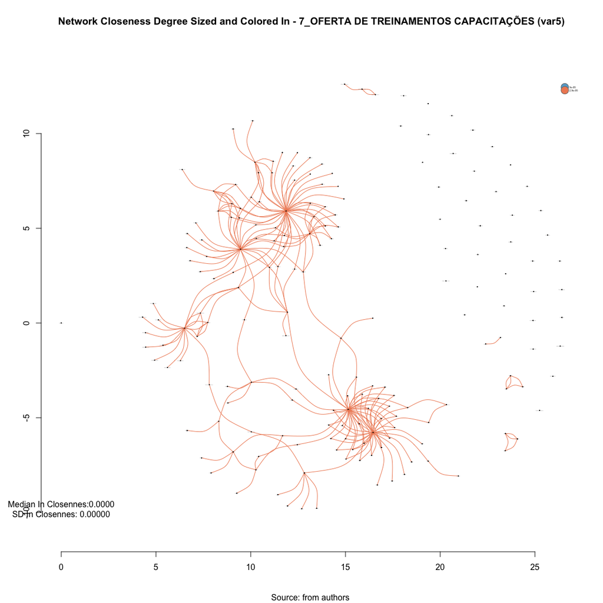

```r
V(var5)$incloseness<-closeness(var5, weights = E(var5)$var5, mode="in")

#Get Variable
V(var5)$var5_color_degree<-round(V(var5)$incloseness,6)

#Creating brewer pallette
vertex_var5_color_degree<-
  colorRampPalette(brewer.pal(length(unique(
          V(var5)$var5_color_degree)), "RdBu"))(
            length(unique(V(var5)$var5_color_degree)))

#Saving as Vertex properties
V(var5)$vertex_var5_color_degree<-
  vertex_var5_color_degree[as.numeric(
  cut(V(var5)$var5_color_degree,
      breaks=length(unique(V(var5)$var5_color_degree))))]

set.seed(123)
#Plotting based only on degree measures
edge.start <- ends(var5, es=E(var5), names=F)[,1]

# Fixing ego
minC <- rep(-Inf, vcount(var5))
maxC <- rep(Inf, vcount(var5))
minC[1] <- maxC[1] <- 0
co <- layout_with_fr(var5, niter=10^4, minx=minC, maxx=maxC,miny=minC, maxy=maxC, weights = E(var5)$weight)


#PLotting
plot(var5,
     layout=co,
     edge.color=V(var5)$vertex_var5_color_degree[edge.start],
     edge.arrow.size=closeness(var5, weights = E(var5)$var5, mode="in"),
     edge.width=E(var5)$weight/mean(E(var5)$weight),
     edge.curved = TRUE,
     vertex.color=V(var5)$vertex_var5_color_degree,
     vertex.size=closeness(var5, weights = E(var5)$var5, mode="in")*10^5,
     vertex.frame.color="black",
     vertex.label.color="black",
     vertex.label=get.vertex.attribute(var5,"LABEL_COR"),
     vertex.label.cex=(closeness(var5, weights = E(var5)$var5, mode="in")+10^-5)*2000,
     vertex.label.dist=0,
     rescale=F,
     xlim=range(co[,1]),
     ylim=range(co[,2])
     )
axis(1)
axis(2)


#Solving Problems with legend rendering
a<-V(var5)$var5_color_degree
b<-V(var5)$vertex_var5_color_degree
c<-table(a,b)
d<-as.data.frame(c)
e<-subset(d, d$Freq>0)
e<-e[order(e$a,decreasing=T),]
f<-t(e$a)
g<-t(e$b)

#Adding Legend
legend(x=range(co[,1])[2],
       y=range(co[,2])[2],
       legend=as.character(f),
       pch=21,
       col = "#777777",
       pt.bg=as.character(g),
       pt.cex=2,
       bty="n",
       ncol=1,
       lty=1,
       cex = .3)

#Adding Title
  title("Network Closeness Degree Sized and Colored In - 7_OFERTA DE TREINAMENTOS CAPACITAÇÕES (var5)", sub = "Source: from authors ")
  text(
    x=range(co[,1])[1],
    y=range(co[,2])[1],
      labels = sprintf(
             "Median In Closennes:%.4f\nSD In Closennes: %.5f",
             median(closeness(var5, mode="in", weights = E(var5)$var5)),
             sd(closeness(var5, mode="in", weights = E(var5)$var5))
             )
       )
```

## 3.3 Closeness Non-normalized - OUT

```r
summary(var5_outcloseness)
```

```
##     Min.  1st Qu.   Median     Mean  3rd Qu.     Max.
## 2.90e-05 2.90e-05 2.90e-05 2.93e-05 2.90e-05 4.10e-05
```

```r
sd(var5_outcloseness)
```

```
## [1] 1.338491e-06
```

### 3.3.1 Network Plotting Based On Non-normalized Closeness - OUT

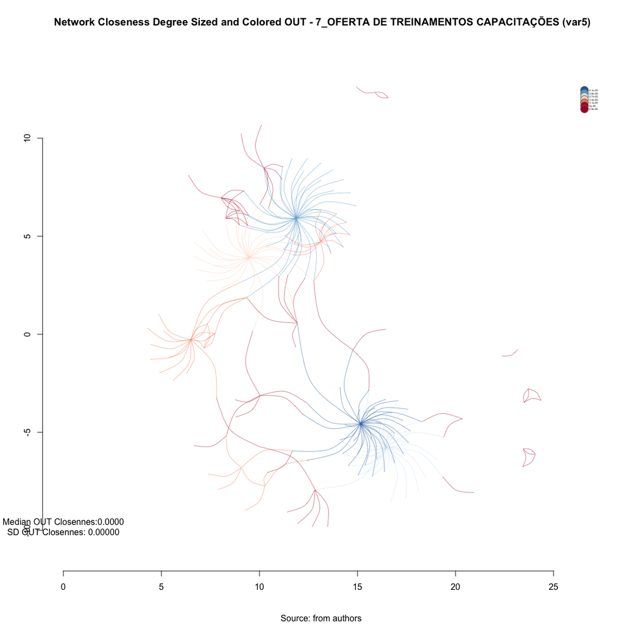

```r
V(var5)$outcloseness<-closeness(var5, weights = E(var5)$var5, mode="out")

#Get Variable
V(var5)$var5_color_degree<-round(V(var5)$outcloseness,6)

#Creating brewer pallette
vertex_var5_color_degree<-
  colorRampPalette(brewer.pal(length(unique(
          V(var5)$var5_color_degree)), "RdBu"))(
            length(unique(V(var5)$var5_color_degree)))

#Saving as Vertex properties
V(var5)$vertex_var5_color_degree<-
  vertex_var5_color_degree[as.numeric(
  cut(V(var5)$var5_color_degree,
      breaks=length(unique(V(var5)$var5_color_degree))))]

set.seed(123)
#Plotting based only on degree measures
edge.start <- ends(var5, es=E(var5), names=F)[,1]

# Fixing ego
minC <- rep(-Inf, vcount(var5))
maxC <- rep(Inf, vcount(var5))
minC[1] <- maxC[1] <- 0
co <- layout_with_fr(var5, niter=10^4, minx=minC, maxx=maxC,miny=minC, maxy=maxC, weights = E(var5)$weight)


#PLotting
plot(var5,
     layout=co,
     edge.color=V(var5)$vertex_var5_color_degree[edge.start],
     edge.arrow.size=closeness(var5, weights = E(var5)$var5, mode="out"),
     edge.width=E(var5)$weight/2*mean(E(var5)$weight),
     edge.curved = TRUE,
     vertex.color=V(var5)$vertex_var5_color_degree,
     vertex.size=closeness(var5, weights = E(var5)$var5, mode="out")*10^4,
     vertex.frame.color="white",
     vertex.label.color="black",
     vertex.label=get.vertex.attribute(var5,"LABEL_COR"),
     vertex.label.cex=closeness(var5, weights = E(var5)$var5, mode="out")*200,
     vertex.label.dist=0,
     rescale=F,
     xlim=range(co[,1]),
     ylim=range(co[,2])
     )
axis(1)
axis(2)


#Solving Problems with legend rendering
a<-V(var5)$var5_color_degree
b<-V(var5)$vertex_var5_color_degree
c<-table(a,b)
d<-as.data.frame(c)
e<-subset(d, d$Freq>0)
e<-e[order(e$a,decreasing=T),]
f<-t(e$a)
g<-t(e$b)

#Adding Legend
legend(x=range(co[,1])[2],
       y=range(co[,2])[2],
       legend=as.character(f),
       pch=21,
       col = "#777777",
       pt.bg=as.character(g),
       pt.cex=2,
       bty="n",
       ncol=1,
       lty=1,
       cex = .3)

#Adding Title
  title("Network Closeness Degree Sized and Colored OUT - 7_OFERTA DE TREINAMENTOS CAPACITAÇÕES (var5)", sub = "Source: from authors ")
  text(
    x=range(co[,1])[1],
    y=range(co[,2])[1],
      labels = sprintf(
             "Median OUT Closennes:%.4f\nSD OUT Closennes: %.5f",
             median(closeness(var5, mode="out", weights = E(var5)$var5)),
             sd(closeness(var5, mode="out", weights = E(var5)$var5))
             )
       )
```

## 3.4 Closeness Non-normalized - ALL

```r
summary(var5_totalcloseness)
```

```
##     Min.  1st Qu.   Median     Mean  3rd Qu.     Max.
## 0.000029 0.000029 0.000101 0.000082 0.000102 0.000103
```

```r
sd(var5_totalcloseness)
```

```
## [1] 3.211337e-05
```

### 3.4.1 Network Plotting Based On Non-normalized Closeness - ALL

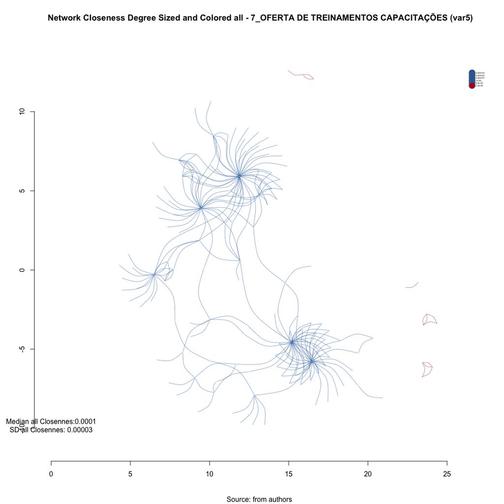

```r
V(var5)$allcloseness<-closeness(var5, weights = E(var5)$var5, mode="all")

#Get Variable
V(var5)$var5_color_degree<-round(V(var5)$allcloseness,6)

#Creating brewer pallette
vertex_var5_color_degree<-
  colorRampPalette(brewer.pal(length(unique(
          V(var5)$var5_color_degree)), "RdBu"))(
            length(unique(V(var5)$var5_color_degree)))

#Saving as Vertex properties
V(var5)$vertex_var5_color_degree<-
  vertex_var5_color_degree[as.numeric(
  cut(V(var5)$var5_color_degree,
      breaks=length(unique(V(var5)$var5_color_degree))))]

set.seed(123)
#Plotting based only on degree measures
edge.start <- ends(var5, es=E(var5), names=F)[,1]

# Fixing ego
minC <- rep(-Inf, vcount(var5))
maxC <- rep(Inf, vcount(var5))
minC[1] <- maxC[1] <- 0
co <- layout_with_fr(var5, niter=10^4, minx=minC, maxx=maxC,miny=minC, maxy=maxC, weights = E(var5)$weight)


#PLotting
plot(var5,
     layout=co,
     edge.color=V(var5)$vertex_var5_color_degree[edge.start],
     edge.arrow.size=closeness(var5, weights = E(var5)$var5, mode="all"),
     edge.width=E(var5)$weight/2*mean(E(var5)$weight),
     edge.curved = TRUE,
     vertex.color=V(var5)$vertex_var5_color_degree,
     vertex.size=closeness(var5, weights = E(var5)$var5, mode="all")*10^4,
     vertex.frame.color="white",
     vertex.label.color="black",
     vertex.label=get.vertex.attribute(var5,"LABEL_COR"),
     vertex.label.cex=(closeness(var5, weights = E(var5)$var5, mode="all")+0.00001)*200,
     vertex.label.dist=0,
     rescale=F,
     xlim=range(co[,1]),
     ylim=range(co[,2])
     )
axis(1)
axis(2)


#Solving Problems with legend rendering
a<-V(var5)$var5_color_degree
b<-V(var5)$vertex_var5_color_degree
c<-table(a,b)
d<-as.data.frame(c)
e<-subset(d, d$Freq>0)
e<-e[order(e$a,decreasing=T),]
f<-t(e$a)
g<-t(e$b)

#Adding Legend
legend(x=range(co[,1])[2],
       y=range(co[,2])[2],
       legend=as.character(f),
       pch=21,
       col = "#777777",
       pt.bg=as.character(g),
       pt.cex=2,
       bty="n",
       ncol=1,
       lty=1,
       cex = .3)

#Adding Title
  title("Network Closeness Degree Sized and Colored all - 7_OFERTA DE TREINAMENTOS CAPACITAÇÕES (var5)", sub = "Source: from authors ")
  text(
    x=range(co[,1])[1],
    y=range(co[,2])[1],
      labels = sprintf(
             "Median all Closennes:%.4f\nSD all Closennes: %.5f",
             median(closeness(var5, mode="all", weights = E(var5)$var5)),
             sd(closeness(var5, mode="all", weights = E(var5)$var5))
             )
       )
```

## 3.5 Closeness Normalized

### 3.5.1 Saving to Igraph object

```r
V(var5)$incloseness_n <- closeness(var5, mode = "in",, weights = E(var5)$var5, normalized = T) %>% round(10)
V(var5)$outcloseness_n <- closeness(var5, mode = "out", normalized = T, weights = E(var5)$var5) %>% round(6)
V(var5)$totalcloseness_n <- closeness(var5, mode = "total", normalized = T, weights = E(var5)$var5) %>% round(6)
```

### 3.5.2 Saving to Environment

```r
var5_incloseness_n<- closeness(var5, mode = "in", normalized = T, weights = E(var5)$var5) %>% round(6)
var5_outcloseness_n<- closeness(var5, mode = "out", normalized = T, weights = E(var5)$var5) %>% round(6)
var5_totalcloseness_n<- closeness(var5, mode = "total", normalized = T, weights = E(var5)$var5) %>% round(6)
```

### 3.5.3 Closeness Normalized - IN

```r
summary(var5_incloseness_n)
```

```
##     Min.  1st Qu.   Median     Mean  3rd Qu.     Max.
## 0.005348 0.005348 0.005405 0.005402 0.005435 0.005617
```

```r
sd(var5_incloseness_n)
```

```
## [1] 4.744273e-05
```

## 3.6 Network Plotting Based On Normalized Closeness - IN

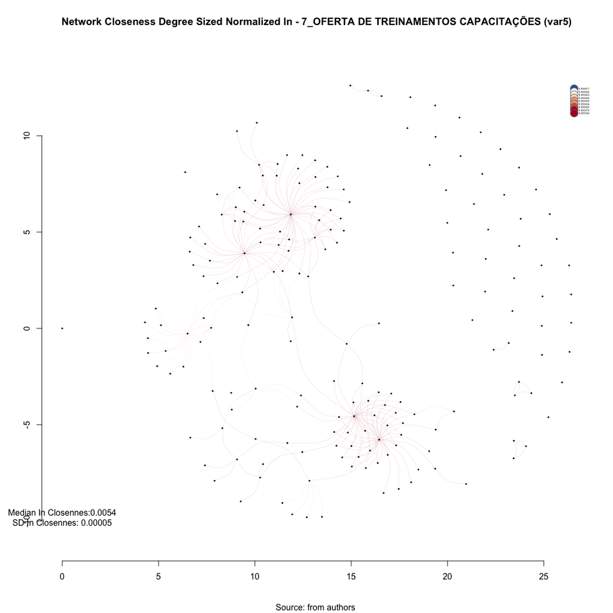

```r
V(var5)$incloseness_n<-closeness(var5, weights = E(var5)$var5, mode="in", normalized = T)

#Get Variable
V(var5)$var5_color_degree<-round(V(var5)$incloseness_n,6)

#Creating brewer pallette
vertex_var5_color_degree<-
  colorRampPalette(brewer.pal(length(unique(
          V(var5)$var5_color_degree)), "RdBu"))(
            length(unique(V(var5)$var5_color_degree)))

#Saving as Vertex properties
V(var5)$vertex_var5_color_degree<-
  vertex_var5_color_degree[as.numeric(
  cut(V(var5)$var5_color_degree,
      breaks=length(unique(V(var5)$var5_color_degree))))]

set.seed(123)
#Plotting based only on degree measures
edge.start <- ends(var5, es=E(var5), names=F)[,1]

# Fixing ego
minC <- rep(-Inf, vcount(var5))
maxC <- rep(Inf, vcount(var5))
minC[1] <- maxC[1] <- 0
co <- layout_with_fr(var5, niter=10^4, minx=minC, maxx=maxC,miny=minC, maxy=maxC, weights = E(var5)$weight)


#PLotting
plot(var5,
     layout=co,
     edge.color=V(var5)$vertex_var5_color_degree[edge.start],
     edge.arrow.size=closeness(var5, weights = E(var5)$var5, mode="in",normalized = T),
     edge.width=E(var5)$weight/10*mean(E(var5)$weight),
     edge.curved = TRUE,
     vertex.color=V(var5)$vertex_var5_color_degree,
     vertex.size=(closeness(var5, weights = E(var5)$var5, mode="in",normalized = T))*1000,
     vertex.frame.color="black",
     vertex.label.color="black",
     vertex.label=get.vertex.attribute(var5,"LABEL_COR"),
     vertex.label.cex=closeness(var5, weights = E(var5)$var5, mode="in",normalized = T)*10,
     vertex.label.dist=0,
     rescale=F,
     xlim=range(co[,1]),
     ylim=range(co[,2])
     )
axis(1)
axis(2)


#Solving Problems with legend rendering
a<-V(var5)$var5_color_degree
b<-V(var5)$vertex_var5_color_degree
c<-table(a,b)
d<-as.data.frame(c)
e<-subset(d, d$Freq>0)
e<-e[order(e$a,decreasing=T),]
f<-t(e$a)
g<-t(e$b)

#Adding Legend
legend(x=range(co[,1])[2],
       y=range(co[,2])[2],
       legend=as.character(f),
       pch=21,
       col = "#777777",
       pt.bg=as.character(g),
       pt.cex=2,
       bty="n",
       ncol=1,
       lty=1,
       cex = .3)

#Adding Title
  title("Network Closeness Degree Sized Normalized In - 7_OFERTA DE TREINAMENTOS CAPACITAÇÕES (var5)", sub = "Source: from authors ")
  text(
    x=range(co[,1])[1],
    y=range(co[,2])[1],
      labels = sprintf(
             "Median In Closennes:%.4f\nSD In Closennes: %.5f",
             median(closeness(var5, mode="in", weights = E(var5)$var5, normalized = T)),
             sd(closeness(var5, mode="in", weights = E(var5)$var5, normalized = T))
             )
       )
```

###Closeness Normalized - OUT

```r
summary(var5_outcloseness_n)
```

```
##     Min.  1st Qu.   Median     Mean  3rd Qu.     Max.
## 0.005348 0.005348 0.005348 0.005411 0.005348 0.007568
```

```r
sd(var5_outcloseness_n)
```

```
## [1] 0.0002555513
```

## 3.7 Network Plotting Based On Normalized Closeness - OUT

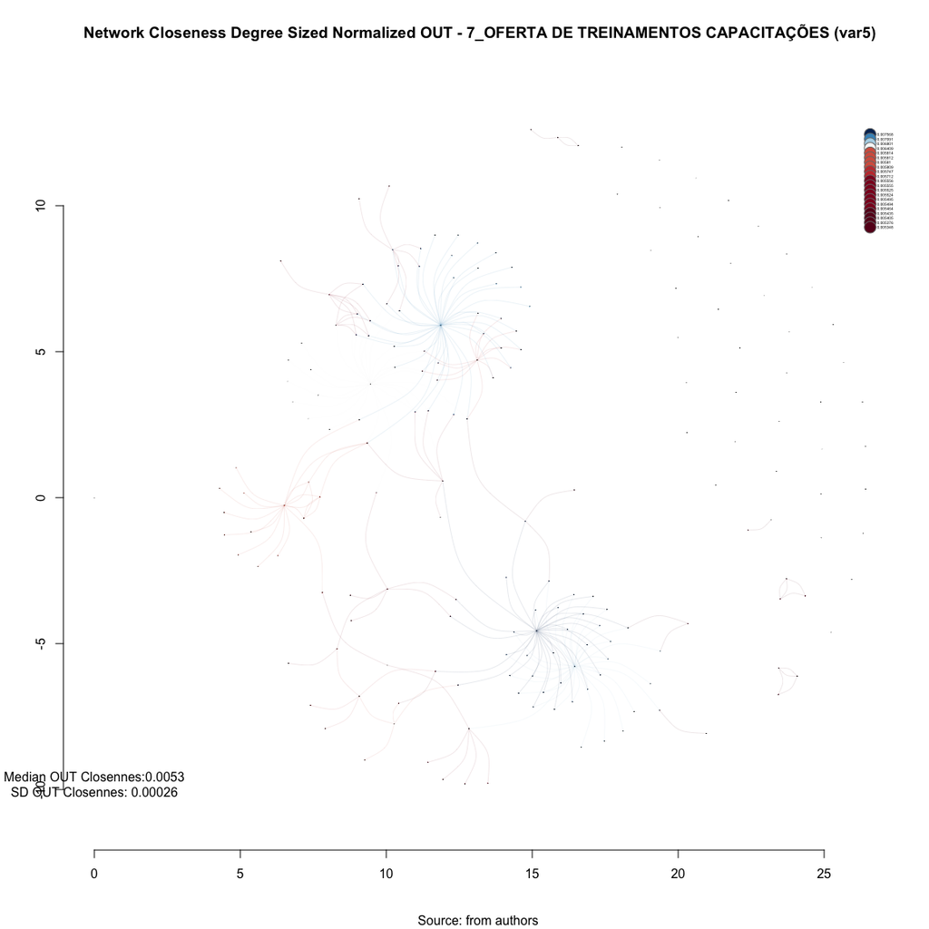

```r
V(var5)$outcloseness_n<-closeness(var5, weights = E(var5)$var5, mode="out", normalized = T)

#Get Variable
V(var5)$var5_color_degree<-round(V(var5)$outcloseness_n,6)

#Creating brewer pallette
vertex_var5_color_degree<-
  colorRampPalette(brewer.pal(length(unique(
          V(var5)$var5_color_degree)), "RdBu"))(
            length(unique(V(var5)$var5_color_degree)))

#Saving as Vertex properties
V(var5)$vertex_var5_color_degree<-
  vertex_var5_color_degree[as.numeric(
  cut(V(var5)$var5_color_degree,
      breaks=length(unique(V(var5)$var5_color_degree))))]

set.seed(123)
#Plotting based only on degree measures
edge.start <- ends(var5, es=E(var5), names=F)[,1]

# Fixing ego
minC <- rep(-Inf, vcount(var5))
maxC <- rep(Inf, vcount(var5))
minC[1] <- maxC[1] <- 0
co <- layout_with_fr(var5, niter=10^4, minx=minC, maxx=maxC,miny=minC, maxy=maxC, weights = E(var5)$weight)


#PLotting
plot(var5,
     layout=co,
     edge.color=V(var5)$vertex_var5_color_degree[edge.start],
     edge.arrow.size=closeness(var5, weights = E(var5)$var5, mode="out",normalized = T),
     edge.width=E(var5)$weight/10*mean(E(var5)$weight),
     edge.curved = TRUE,
     vertex.color=V(var5)$vertex_var5_color_degree,
     vertex.size=(closeness(var5, weights = E(var5)$var5, mode="out",normalized = T))*100,
     vertex.frame.color="black",
     vertex.label.color="black",
     vertex.label=get.vertex.attribute(var5,"LABEL_COR"),
     vertex.label.cex=closeness(var5, weights = E(var5)$var5, mode="out",normalized = T)*1.5,
     vertex.label.dist=0,
     rescale=F,
     xlim=range(co[,1]),
     ylim=range(co[,2])
     )
axis(1)
axis(2)


#Solving Problems with legend rendering
a<-V(var5)$var5_color_degree
b<-V(var5)$vertex_var5_color_degree
c<-table(a,b)
d<-as.data.frame(c)
e<-subset(d, d$Freq>0)
e<-e[order(e$a,decreasing=T),]
f<-t(e$a)
g<-t(e$b)

#Adding Legend
legend(x=range(co[,1])[2],
       y=range(co[,2])[2],
       legend=as.character(f),
       pch=21,
       col = "#777777",
       pt.bg=as.character(g),
       pt.cex=2,
       bty="n",
       ncol=1,
       lty=1,
       cex = .3)

#Adding Title
  title("Network Closeness Degree Sized Normalized OUT - 7_OFERTA DE TREINAMENTOS CAPACITAÇÕES (var5)", sub = "Source: from authors ")
  text(
    x=range(co[,1])[1],
    y=range(co[,2])[1],
      labels = sprintf(
             "Median OUT Closennes:%.4f\nSD OUT Closennes: %.5f",
             median(closeness(var5, mode="out", weights = E(var5)$var5, normalized = T)),
             sd(closeness(var5, mode="out", weights = E(var5)$var5, normalized = T))
             )
       )
```

### 3.7.1 Closeness Normalized - ALL

```r
summary(var5_totalcloseness_n)
```

```
##     Min.  1st Qu.   Median     Mean  3rd Qu.     Max.
## 0.005348 0.005405 0.018810 0.015230 0.018920 0.019180
```

```r
sd(var5_totalcloseness_n)
```

```
## [1] 0.005983484
```

## 3.8 Network Plotting Based On Normalized Closeness - ALL

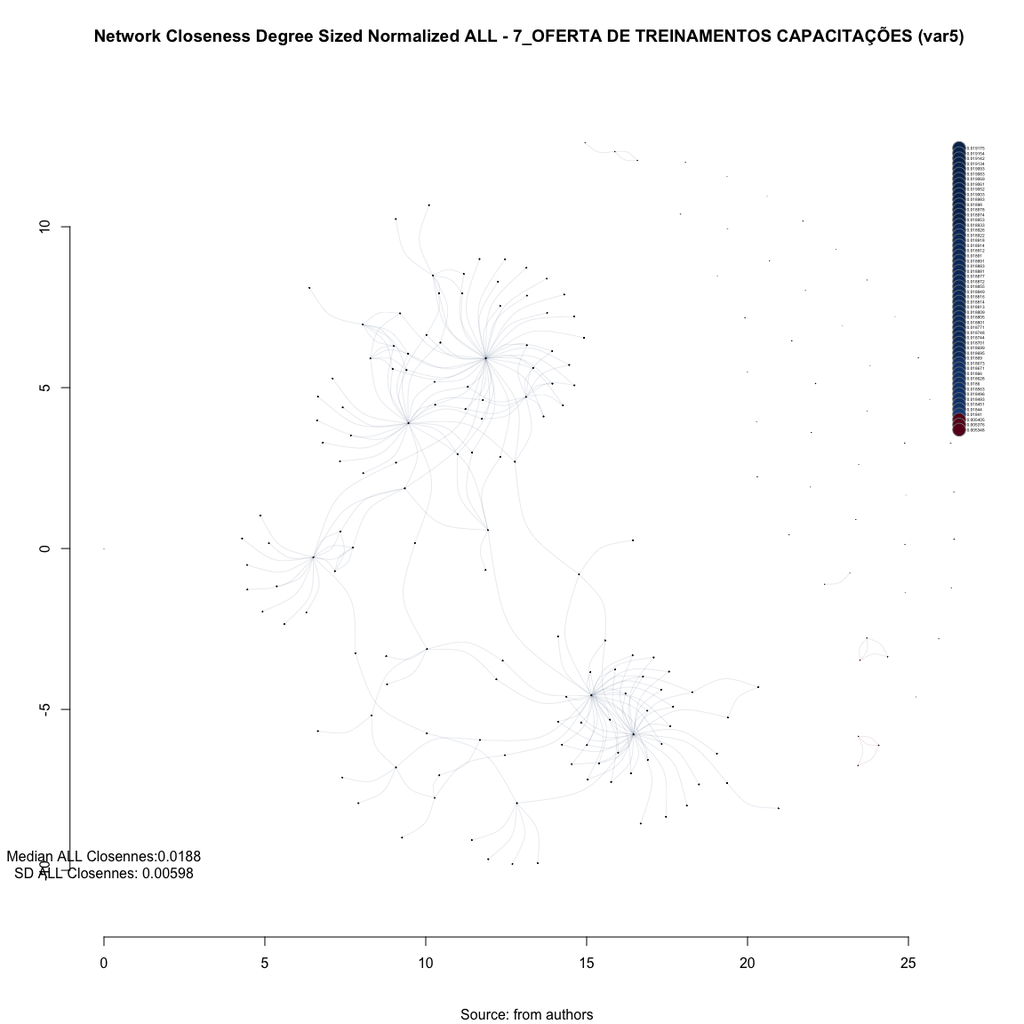

```r
V(var5)$allcloseness_n<-closeness(var5, weights = E(var5)$var5, mode="all", normalized = T)

#Get Variable
V(var5)$var5_color_degree<-round(V(var5)$allcloseness_n,6)

#Creating brewer pallette
vertex_var5_color_degree<-
  colorRampPalette(brewer.pal(length(unique(
          V(var5)$var5_color_degree)), "RdBu"))(
            length(unique(V(var5)$var5_color_degree)))

#Saving as Vertex properties
V(var5)$vertex_var5_color_degree<-
  vertex_var5_color_degree[as.numeric(
  cut(V(var5)$var5_color_degree,
      breaks=length(unique(V(var5)$var5_color_degree))))]

set.seed(123)
#Plotting based only on degree measures
edge.start <- ends(var5, es=E(var5), names=F)[,1]

# Fixing ego
minC <- rep(-Inf, vcount(var5))
maxC <- rep(Inf, vcount(var5))
minC[1] <- maxC[1] <- 0
co <- layout_with_fr(var5, niter=10^4, minx=minC, maxx=maxC,miny=minC, maxy=maxC, weights = E(var5)$weight)


#PLotting
plot(var5,
     layout=co,
     edge.color=V(var5)$vertex_var5_color_degree[edge.start],
     edge.arrow.size=closeness(var5, weights = E(var5)$var5, mode="all",normalized = T),
     edge.width=E(var5)$weight/10*mean(E(var5)$weight),
     edge.curved = TRUE,
     vertex.color=V(var5)$vertex_var5_color_degree,
     vertex.size=(closeness(var5, weights = E(var5)$var5, mode="all",normalized = T))*100,
     vertex.frame.color="black",
     vertex.label.color="black",
     vertex.label=get.vertex.attribute(var5,"LABEL_COR"),
     vertex.label.cex=closeness(var5, weights = E(var5)$var5, mode="all",normalized = T)*1.5,
     vertex.label.dist=0,
     rescale=F,
     xlim=range(co[,1]),
     ylim=range(co[,2])
     )
axis(1)
axis(2)


#Solving Problems with legend rendering
a<-V(var5)$var5_color_degree
b<-V(var5)$vertex_var5_color_degree
c<-table(a,b)
d<-as.data.frame(c)
e<-subset(d, d$Freq>0)
e<-e[order(e$a,decreasing=T),]
f<-t(e$a)
g<-t(e$b)

#Adding Legend
legend(x=range(co[,1])[2],
       y=range(co[,2])[2],
       legend=as.character(f),
       pch=21,
       col = "#777777",
       pt.bg=as.character(g),
       pt.cex=2,
       bty="n",
       ncol=1,
       lty=1,
       cex = .3)

#Adding Title
  title("Network Closeness Degree Sized Normalized ALL - 7_OFERTA DE TREINAMENTOS CAPACITAÇÕES (var5)", sub = "Source: from authors ")
  text(
    x=range(co[,1])[1],
    y=range(co[,2])[1],
      labels = sprintf(
             "Median ALL Closennes:%.4f\nSD ALL Closennes: %.5f",
             median(closeness(var5, mode="all", weights = E(var5)$var5, normalized = T)),
             sd(closeness(var5, mode="all", weights = E(var5)$var5, normalized = T))
             )
       )
```

## 3.9 Closeness Normalized

### 3.9.1 Saving to Igraph object

```r
V(var5)$incloseness_n <- closeness(var5, weights = E(var5)$var5, mode = "in", normalized = T) %>% round(6)
V(var5)$outcloseness_n <- closeness(var5, weights = E(var5)$var5, mode = "out", normalized = T) %>% round(6)
V(var5)$totalcloseness_n <- closeness(var5, weights = E(var5)$var5, mode = "total", normalized = T) %>% round(6)
```

## 3.10 Centralization Closseness

```r
V(var5)$var5_centr_closeness<- centralization.closeness(var5)$res
var5_centr_closeness<- centralization.closeness(var5)$res
var5_centr_closeness_all<- centralization.closeness(var5)
```

### 3.10.1 Centralization

```r
var5_centr_closeness_all$centralization
```

```
## [1] 0.002180822
```

### 3.10.2 Theoretical Max

```r
var5_centr_closeness_all$theoretical_max
```

```
## [1] 185.0053
```

## 3.11 Network Plotting Based On Centralization Closeness

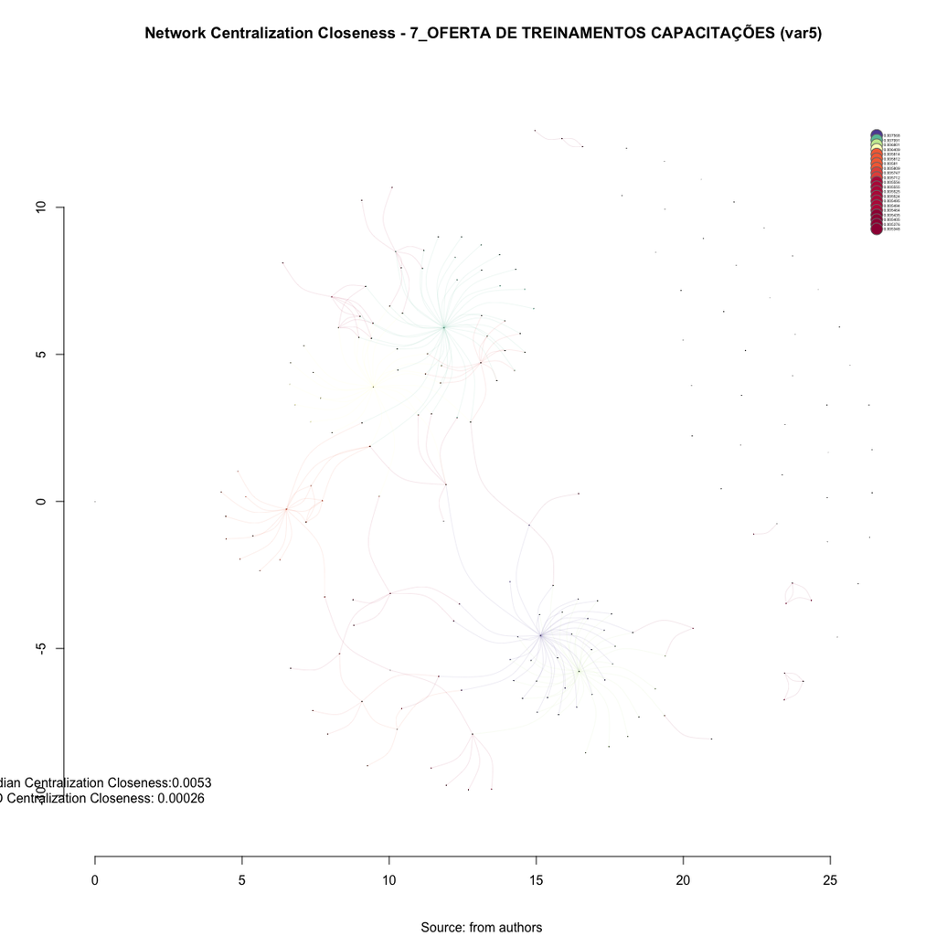

```r
V(var5)$var5_centr_closeness<- centralization.closeness(var5)$res

#Get Variable
V(var5)$var5_color_degree<-round(V(var5)$var5_centr_closeness,6)

#Creating brewer pallette
vertex_var5_color_degree<-
  colorRampPalette(brewer.pal(length(unique(
          V(var5)$var5_color_degree)), "Spectral"))(
            length(unique(V(var5)$var5_color_degree)))

#Saving as Vertex properties
V(var5)$vertex_var5_color_degree<-
  vertex_var5_color_degree[as.numeric(
  cut(V(var5)$var5_color_degree,
      breaks=length(unique(V(var5)$var5_color_degree))))]

set.seed(123)
#Plotting based only on degree measures
edge.start <- ends(var5, es=E(var5), names=F)[,1]

# Fixing ego
minC <- rep(-Inf, vcount(var5))
maxC <- rep(Inf, vcount(var5))
minC[1] <- maxC[1] <- 0
co <- layout_with_fr(var5, niter=10^4, minx=minC, maxx=maxC,miny=minC, maxy=maxC, weights = E(var5)$weight)


#PLotting
plot(var5,
     layout=co,
     edge.color=V(var5)$vertex_var5_color_degree[edge.start],
     edge.arrow.size=centralization.closeness(var5)$res,
     edge.width=E(var5)$weight/10*mean(E(var5)$weight),
     edge.curved = TRUE,
     vertex.color=V(var5)$vertex_var5_color_degree,
     vertex.size=centralization.closeness(var5)$res*100,
     vertex.frame.color="black",
     vertex.label.color="black",
     vertex.label=get.vertex.attribute(var5,"LABEL_COR"),
     vertex.label.cex=centralization.closeness(var5)$res,
     vertex.label.dist=0,
     rescale=F,
     xlim=range(co[,1]),
     ylim=range(co[,2])
     )
axis(1)
axis(2)


#Solving Problems with legend rendering
a<-V(var5)$var5_color_degree
b<-V(var5)$vertex_var5_color_degree
c<-table(a,b)
d<-as.data.frame(c)
e<-subset(d, d$Freq>0)
e<-e[order(e$a,decreasing=T),]
f<-t(e$a)
g<-t(e$b)

#Adding Legend
legend(x=range(co[,1])[2],
       y=range(co[,2])[2],
       legend=as.character(f),
       pch=21,
       col = "#777777",
       pt.bg=as.character(g),
       pt.cex=2,
       bty="n",
       ncol=1,
       lty=1,
       cex = .3)

#Adding Title
  title("Network Centralization Closeness - 7_OFERTA DE TREINAMENTOS CAPACITAÇÕES (var5)", sub = "Source: from authors ")
  text(
    x=range(co[,1])[1],
    y=range(co[,2])[1],
      labels = sprintf(
             "Median Centralization Closeness:%.4f\nSD Centralization Closeness: %.5f",
             median(centralization.closeness(var5)$res),
             sd(centralization.closeness(var5)$res)
             )
       )
```

# 4 Closeness Dinamic Table

## 4.1 Getting Closeness Measures

```r
var5_incloseness<- closeness(var5, weights = E(var5)$var5, mode = "in") %>% round(6)
var5_outcloseness<- closeness(var5, weights = E(var5)$var5, mode = "out") %>% round(6)
var5_totalcloseness<- closeness(var5, weights = E(var5)$var5, mode = "total") %>% round(6)
var5_incloseness_n<- closeness(var5,weights = E(var5)$var5, mode = "in", normalized = T) %>% round(6)
var5_outcloseness_n<- closeness(var5,weights = E(var5)$var5, mode = "out", normalized = T) %>% round(6)
var5_totalcloseness_n<- closeness(var5,weights = E(var5)$var5, mode = "total", normalized = T) %>% round(6)
var5_centr_closeness <- centralization.closeness(var5)$res %>% round(6)
```

## 4.2 Creating a datagrame of measures

```r
var5_df_closseness <- data.frame(
var5_incloseness,
var5_outcloseness,
var5_totalcloseness,
var5_incloseness_n,
var5_outcloseness_n,
var5_totalcloseness_n,
var5_centr_closeness) %>% round(6)

#Adding type
var5_df_closseness <-cbind(var5_df_closseness, V(var5)$LABEL_COR)

#Adding names
names(var5_df_closseness) <- c("In Closeness", "Out Closeness", "Total Closeness","In Closeness Normalized", "Out Closeness Normalized", "Total Closeness Normalized","Centralization Closeness","Type")

#Ordering Variables
var5_df_closseness<-var5_df_closseness[c("Type","In Closeness", "Out Closeness", "Total Closeness","In Closeness Normalized", "Out Closeness Normalized","Total Closeness Normalized", "Centralization Closeness")]
```

## 4.3 General tabel - DT

```r
datatable(var5_df_closseness, filter = 'top')
```

|  | Type | In Closeness | Out Closeness | Total Closeness | In Closeness Normalized | Out Closeness Normalized | Total Closeness Normalized | Centralization Closeness |
| --- | --- | --- | --- | --- | --- | --- | --- | --- |
| ASS_HOS_ Hospital de Pronto Socorro – HPS | Pronto Socorro | 2.9e-05 | 2.9e-05 | 2.9e-05 | 0.005348 | 0.005348 | 0.005348 | 0.005348 |
| AMB_SAM_ Centro de Atenção à Saúde Mental (CASM) | Ambulatório de Saúde Mental | 2.9e-05 | 2.9e-05 | 2.9e-05 | 0.005348 | 0.005348 | 0.005348 | 0.005348 |
| CAPS_AD | CAPSAD | 2.9e-05 | 2.9e-05 | 0.000103 | 0.005435 | 0.005464 | 0.019175 | 0.005464 |
| CRAS_AS_ CRAS Sudeste Costa Carvalho | CRAS | 2.9e-05 | 3e-05 | 0.000101 | 0.005376 | 0.005556 | 0.018855 | 0.005556 |
| CRE_SOC_ CREAS Infância e Juventude | CREAS | 2.9e-05 | 2.9e-05 | 2.9e-05 | 0.005348 | 0.005348 | 0.005348 | 0.005348 |
| CRE_SOC_ CREAS Norte | CREAS | 2.9e-05 | 2.9e-05 | 2.9e-05 | 0.005348 | 0.005348 | 0.005348 | 0.005348 |
| ASS_HOS_ Serviço de Controle e Prevenção e Tratamento do Tabagismo (SECOPTT) | Ambulatório Tabagismo | 2.9e-05 | 3.4e-05 | 0.000103 | 0.005348 | 0.006409 | 0.019134 | 0.006409 |
| EA_DQCT_ Centro de Recuperação Resgatando Vidas (Escritório) | Clínicas e CT | 2.9e-05 | 3e-05 | 0.0001 | 0.005405 | 0.005555 | 0.01866 | 0.005555 |
| EA_DQCT_ Comunidade Terapêutica Geração de Adoradores – CTGA | Clínicas e CT | 2.9e-05 | 2.9e-05 | 9.9e-05 | 0.005376 | 0.005348 | 0.01844 | 0.005348 |
| EA_DQCT_ Centro de Recuperação Resgatando Vidas | Clínicas e CT | 2.9e-05 | 2.9e-05 | 9.9e-05 | 0.005434 | 0.005348 | 0.01841 | 0.005348 |

[output cut: 177 more lines]

## 4.4 Aggregating data from previous table - mean

```r
aggdata_mean <-aggregate(var5_df_closseness, by=list(var5_df_closseness$Type), FUN=mean, na.rm=TRUE)

names(aggdata_mean) <- c("Group","Type","In Closeness(M)", "Out Closeness(M)", "Total Closeness(M)","In Closeness Normalized(M)", "Out Closeness Normalized(M)", "Total Closeness Normalized(M)","Centralization Closeness(M)")

#Removing Type variable
aggdata_mean<-aggdata_mean[,-c(2)]
```

## 4.5 Aggregating data from previous table - sd

```r
aggdata_sd <-aggregate(var5_df_closseness, by=list(var5_df_closseness$Type), FUN=sd, na.rm=TRUE)

names(aggdata_sd) <- c("Group","Type","In Closeness(SD)", "Out Closeness(SD)", "Total Closeness(SD)","In Closeness Normalized(SD)", "Out Closeness Normalized(SD)", "Total Closeness Normalized(SD)", "Centralization Closeness(SD)")

#Removing Type variable
aggdata_sd<-aggdata_sd[,-c(2)]

#Merging mean and standart deviation
total_table <- merge(aggdata_mean,aggdata_sd,by="Group")

#Rounding
Group<-total_table[,c(1)] #Keeping group
total_table<-total_table[,-c(1)] %>% round(6) #Rouding
total_table<-cbind(Group,total_table) #Binding toghter

#Organizing Variabels
total_table<-total_table[c("Group","In Closeness(M)", "In Closeness(SD)", "Out Closeness(M)", "Out Closeness(SD)", "Total Closeness(M)","Total Closeness(SD)","In Closeness Normalized(M)", "In Closeness Normalized(SD)", "Out Closeness Normalized(M)", "Out Closeness Normalized(SD)", "Total Closeness Normalized(M)","Total Closeness Normalized(SD)", "Centralization Closeness(M)","Centralization Closeness(SD)")]
```

## 4.6 Plotting final table with round for Closseness

```r
datatable(total_table, filter = 'top')
```

|  | Group | In Closeness(M) | In Closeness(SD) | Out Closeness(M) | Out Closeness(SD) | Total Closeness(M) | Total Closeness(SD) | In Closeness Normalized(M) | In Closeness Normalized(SD) | Out Closeness Normalized(M) | Out Closeness Normalized(SD) | Total Closeness Normalized(M) | Total Closeness Normalized(SD) | Centralization Closeness(M) | Centralization Closeness(SD) |
| --- | --- | --- | --- | --- | --- | --- | --- | --- | --- | --- | --- | --- | --- | --- | --- |
| 1 | Acolhimento Institucional | 2.9e-05 | 0 | 2.9e-05 | 0 | 7.7e-05 | 4.2e-05 | 0.005425 | 6.7e-05 | 0.005348 | 0 | 0.014246 | 0.007706 | 0.005348 | 0 |
| 2 | Ajuda Mútua | 2.9e-05 | 0 | 2.9e-05 | 2e-06 | 9.8e-05 | 1.5e-05 | 0.005405 | 2.7e-05 | 0.005444 | 0.00039 | 0.018277 | 0.00279 | 0.005444 | 0.00039 |
| 3 | Ambulatório AD | 2.9e-05 |  | 3e-05 |  | 0.000102 |  | 0.005376 |  | 0.005555 |  | 0.018933 |  | 0.005555 |  |
| 4 | Ambulatório de Saúde Mental | 2.9e-05 |  | 2.9e-05 |  | 2.9e-05 |  | 0.005348 |  | 0.005348 |  | 0.005348 |  | 0.005348 |  |
| 5 | Ambulatório Tabagismo | 2.9e-05 |  | 3.4e-05 |  | 0.000103 |  | 0.005348 |  | 0.006409 |  | 0.019134 |  | 0.006409 |  |
| 6 | Assistência Hospitalar | 2.9e-05 |  | 2.9e-05 |  | 0.000102 |  | 0.005405 |  | 0.005348 |  | 0.01891 |  | 0.005348 |  |
| 7 | CAPS | 2.9e-05 | 0 | 3e-05 | 1e-06 | 7.7e-05 | 4.2e-05 | 0.005387 | 6.7e-05 | 0.00554 | 0.0002 | 0.014323 | 0.007773 | 0.00554 | 0.0002 |
| 8 | CAPSAD | 2.9e-05 |  | 2.9e-05 |  | 0.000103 |  | 0.005435 |  | 0.005464 |  | 0.019175 |  | 0.005464 |  |
| 9 | CAPSi | 2.9e-05 |  | 2.9e-05 |  | 2.9e-05 |  | 0.005348 |  | 0.005348 |  | 0.005348 |  | 0.005348 |  |
| 10 | Centro de Convivência | 2.9e-05 |  | 2.9e-05 |  | 0.0001 |  | 0.005464 |  | 0.005348 |  | 0.018673 |  | 0.005348 |  |

[output cut: 13 more lines]

## 4.7 Creating a datagrame of measures (Natureza Governamental)

```r
var5_df_closseness <- data.frame(
var5_incloseness,
var5_outcloseness,
var5_totalcloseness,
var5_incloseness_n,
var5_outcloseness_n,
var5_totalcloseness_n,
var5_centr_closeness) %>% round(6)

#Adding type
var5_df_closseness <-cbind(var5_df_closseness, V(var5)$TIPO1)

#Adding names
names(var5_df_closseness) <- c("In Closeness", "Out Closeness", "Total Closeness","In Closeness Normalized", "Out Closeness Normalized", "Total Closeness Normalized","Centralization Closeness","Type")

#Ordering Variables
var5_df_closseness<-var5_df_closseness[c("Type","In Closeness", "Out Closeness", "Total Closeness","In Closeness Normalized", "Out Closeness Normalized","Total Closeness Normalized", "Centralization Closeness")]
```

## 4.8 General tabel - DT

```r
datatable(var5_df_closseness, filter = 'top')
```

|  | Type | In Closeness | Out Closeness | Total Closeness | In Closeness Normalized | Out Closeness Normalized | Total Closeness Normalized | Centralization Closeness |
| --- | --- | --- | --- | --- | --- | --- | --- | --- |
| ASS_HOS_ Hospital de Pronto Socorro – HPS | Governamental | 2.9e-05 | 2.9e-05 | 2.9e-05 | 0.005348 | 0.005348 | 0.005348 | 0.005348 |
| AMB_SAM_ Centro de Atenção à Saúde Mental (CASM) | Governamental | 2.9e-05 | 2.9e-05 | 2.9e-05 | 0.005348 | 0.005348 | 0.005348 | 0.005348 |
| CAPS_AD | Governamental | 2.9e-05 | 2.9e-05 | 0.000103 | 0.005435 | 0.005464 | 0.019175 | 0.005464 |
| CRAS_AS_ CRAS Sudeste Costa Carvalho | Governamental | 2.9e-05 | 3e-05 | 0.000101 | 0.005376 | 0.005556 | 0.018855 | 0.005556 |
| CRE_SOC_ CREAS Infância e Juventude | Governamental | 2.9e-05 | 2.9e-05 | 2.9e-05 | 0.005348 | 0.005348 | 0.005348 | 0.005348 |
| CRE_SOC_ CREAS Norte | Governamental | 2.9e-05 | 2.9e-05 | 2.9e-05 | 0.005348 | 0.005348 | 0.005348 | 0.005348 |
| ASS_HOS_ Serviço de Controle e Prevenção e Tratamento do Tabagismo (SECOPTT) | Governamental | 2.9e-05 | 3.4e-05 | 0.000103 | 0.005348 | 0.006409 | 0.019134 | 0.006409 |
| EA_DQCT_ Centro de Recuperação Resgatando Vidas (Escritório) | Não Governamental | 2.9e-05 | 3e-05 | 0.0001 | 0.005405 | 0.005555 | 0.01866 | 0.005555 |
| EA_DQCT_ Comunidade Terapêutica Geração de Adoradores – CTGA | Não Governamental | 2.9e-05 | 2.9e-05 | 9.9e-05 | 0.005376 | 0.005348 | 0.01844 | 0.005348 |
| EA_DQCT_ Centro de Recuperação Resgatando Vidas | Não Governamental | 2.9e-05 | 2.9e-05 | 9.9e-05 | 0.005434 | 0.005348 | 0.01841 | 0.005348 |

[output cut: 177 more lines]

## 4.9 Aggregating data from previous table - mean

```r
aggdata_mean <-aggregate(var5_df_closseness, by=list(var5_df_closseness$Type), FUN=mean, na.rm=TRUE)

names(aggdata_mean) <- c("Group","Type","In Closeness(M)", "Out Closeness(M)", "Total Closeness(M)","In Closeness Normalized(M)", "Out Closeness Normalized(M)", "Total Closeness Normalized(M)","Centralization Closeness(M)")

#Removing Type variable
aggdata_mean<-aggdata_mean[,-c(2)]
```

## 4.10 Aggregating data from previous table - sd

```r
aggdata_sd <-aggregate(var5_df_closseness, by=list(var5_df_closseness$Type), FUN=sd, na.rm=TRUE)

names(aggdata_sd) <- c("Group","Type","In Closeness(SD)", "Out Closeness(SD)", "Total Closeness(SD)","In Closeness Normalized(SD)", "Out Closeness Normalized(SD)", "Total Closeness Normalized(SD)", "Centralization Closeness(SD)")

#Removing Type variable
aggdata_sd<-aggdata_sd[,-c(2)]

#Merging mean and standart deviation
total_table <- merge(aggdata_mean,aggdata_sd,by="Group")

#Rounding
Group<-total_table[,c(1)] #Keeping group
total_table<-total_table[,-c(1)] %>% round(6) #Rouding
total_table<-cbind(Group,total_table) #Binding toghter

#Organizing Variabels
total_table<-total_table[c("Group","In Closeness(M)", "In Closeness(SD)", "Out Closeness(M)", "Out Closeness(SD)", "Total Closeness(M)","Total Closeness(SD)","In Closeness Normalized(M)", "In Closeness Normalized(SD)", "Out Closeness Normalized(M)", "Out Closeness Normalized(SD)", "Total Closeness Normalized(M)","Total Closeness Normalized(SD)", "Centralization Closeness(M)","Centralization Closeness(SD)")]
```

## 4.11 Plotting final table with round for Closseness

```r
datatable(total_table, filter = 'top')
```

|  | Group | In Closeness(M) | In Closeness(SD) | Out Closeness(M) | Out Closeness(SD) | Total Closeness(M) | Total Closeness(SD) | In Closeness Normalized(M) | In Closeness Normalized(SD) | Out Closeness Normalized(M) | Out Closeness Normalized(SD) | Total Closeness Normalized(M) | Total Closeness Normalized(SD) | Centralization Closeness(M) | Centralization Closeness(SD) |
| --- | --- | --- | --- | --- | --- | --- | --- | --- | --- | --- | --- | --- | --- | --- | --- |
| 1 | Governamental | 2.9e-05 | 0 | 2.9e-05 | 1e-06 | 8.1e-05 | 3.3e-05 | 0.005403 | 5.5e-05 | 0.005399 | 0.000213 | 0.01498 | 0.006141 | 0.005399 | 0.000213 |
| 2 | Não Governamental | 2.9e-05 | 0 | 2.9e-05 | 2e-06 | 8.4e-05 | 3.1e-05 | 0.005399 | 3.4e-05 | 0.005428 | 0.000305 | 0.015584 | 0.005782 | 0.005428 | 0.000305 |

## 4.12 Creating a datagrame of measures (Setores)

```r
var5_df_closseness <- data.frame(
var5_incloseness,
var5_outcloseness,
var5_totalcloseness,
var5_incloseness_n,
var5_outcloseness_n,
var5_totalcloseness_n,
var5_centr_closeness) %>% round(6)

#Adding type
var5_df_closseness <-cbind(var5_df_closseness, V(var5)$TIPO2)

#Adding names
names(var5_df_closseness) <- c("In Closeness", "Out Closeness", "Total Closeness","In Closeness Normalized", "Out Closeness Normalized", "Total Closeness Normalized","Centralization Closeness","Type")

#Ordering Variables
var5_df_closseness<-var5_df_closseness[c("Type","In Closeness", "Out Closeness", "Total Closeness","In Closeness Normalized", "Out Closeness Normalized","Total Closeness Normalized", "Centralization Closeness")]
```

## 4.13 General tabel - DT

```r
datatable(var5_df_closseness, filter = 'top')
```

|  | Type | In Closeness | Out Closeness | Total Closeness | In Closeness Normalized | Out Closeness Normalized | Total Closeness Normalized | Centralization Closeness |
| --- | --- | --- | --- | --- | --- | --- | --- | --- |
| ASS_HOS_ Hospital de Pronto Socorro – HPS | Saúde | 2.9e-05 | 2.9e-05 | 2.9e-05 | 0.005348 | 0.005348 | 0.005348 | 0.005348 |
| AMB_SAM_ Centro de Atenção à Saúde Mental (CASM) | Saúde | 2.9e-05 | 2.9e-05 | 2.9e-05 | 0.005348 | 0.005348 | 0.005348 | 0.005348 |
| CAPS_AD | Saúde | 2.9e-05 | 2.9e-05 | 0.000103 | 0.005435 | 0.005464 | 0.019175 | 0.005464 |
| CRAS_AS_ CRAS Sudeste Costa Carvalho | Assistência Social | 2.9e-05 | 3e-05 | 0.000101 | 0.005376 | 0.005556 | 0.018855 | 0.005556 |
| CRE_SOC_ CREAS Infância e Juventude | Assistência Social | 2.9e-05 | 2.9e-05 | 2.9e-05 | 0.005348 | 0.005348 | 0.005348 | 0.005348 |
| CRE_SOC_ CREAS Norte | Assistência Social | 2.9e-05 | 2.9e-05 | 2.9e-05 | 0.005348 | 0.005348 | 0.005348 | 0.005348 |
| ASS_HOS_ Serviço de Controle e Prevenção e Tratamento do Tabagismo (SECOPTT) | Saúde | 2.9e-05 | 3.4e-05 | 0.000103 | 0.005348 | 0.006409 | 0.019134 | 0.006409 |
| EA_DQCT_ Centro de Recuperação Resgatando Vidas (Escritório) | Terceiro Setor | 2.9e-05 | 3e-05 | 0.0001 | 0.005405 | 0.005555 | 0.01866 | 0.005555 |
| EA_DQCT_ Comunidade Terapêutica Geração de Adoradores – CTGA | Terceiro Setor | 2.9e-05 | 2.9e-05 | 9.9e-05 | 0.005376 | 0.005348 | 0.01844 | 0.005348 |
| EA_DQCT_ Centro de Recuperação Resgatando Vidas | Terceiro Setor | 2.9e-05 | 2.9e-05 | 9.9e-05 | 0.005434 | 0.005348 | 0.01841 | 0.005348 |

[output cut: 177 more lines]

## 4.14 Aggregating data from previous table - mean

```r
aggdata_mean <-aggregate(var5_df_closseness, by=list(var5_df_closseness$Type), FUN=mean, na.rm=TRUE)

names(aggdata_mean) <- c("Group","Type","In Closeness(M)", "Out Closeness(M)", "Total Closeness(M)","In Closeness Normalized(M)", "Out Closeness Normalized(M)", "Total Closeness Normalized(M)","Centralization Closeness(M)")

#Removing Type variable
aggdata_mean<-aggdata_mean[,-c(2)]
```

## 4.15 Aggregating data from previous table - sd

```r
aggdata_sd <-aggregate(var5_df_closseness, by=list(var5_df_closseness$Type), FUN=sd, na.rm=TRUE)

names(aggdata_sd) <- c("Group","Type","In Closeness(SD)", "Out Closeness(SD)", "Total Closeness(SD)","In Closeness Normalized(SD)", "Out Closeness Normalized(SD)", "Total Closeness Normalized(SD)", "Centralization Closeness(SD)")

#Removing Type variable
aggdata_sd<-aggdata_sd[,-c(2)]

#Merging mean and standart deviation
total_table <- merge(aggdata_mean,aggdata_sd,by="Group")

#Rounding
Group<-total_table[,c(1)] #Keeping group
total_table<-total_table[,-c(1)] %>% round(6) #Rouding
total_table<-cbind(Group,total_table) #Binding toghter

#Organizing Variabels
total_table<-total_table[c("Group","In Closeness(M)", "In Closeness(SD)", "Out Closeness(M)", "Out Closeness(SD)", "Total Closeness(M)","Total Closeness(SD)","In Closeness Normalized(M)", "In Closeness Normalized(SD)", "Out Closeness Normalized(M)", "Out Closeness Normalized(SD)", "Total Closeness Normalized(M)","Total Closeness Normalized(SD)", "Centralization Closeness(M)","Centralization Closeness(SD)")]
```

## 4.16 Plotting final table with round for Closseness

```r
datatable(total_table, filter = 'top')
```

|  | Group | In Closeness(M) | In Closeness(SD) | Out Closeness(M) | Out Closeness(SD) | Total Closeness(M) | Total Closeness(SD) | In Closeness Normalized(M) | In Closeness Normalized(SD) | Out Closeness Normalized(M) | Out Closeness Normalized(SD) | Total Closeness Normalized(M) | Total Closeness Normalized(SD) | Centralization Closeness(M) | Centralization Closeness(SD) |
| --- | --- | --- | --- | --- | --- | --- | --- | --- | --- | --- | --- | --- | --- | --- | --- |
| 1 | Assistência Social | 2.9e-05 | 0 | 3e-05 | 2e-06 | 9.2e-05 | 2.5e-05 | 0.005396 | 4.6e-05 | 0.005509 | 0.000456 | 0.017016 | 0.004738 | 0.005509 | 0.000456 |
| 2 | Saúde | 2.9e-05 | 0 | 2.9e-05 | 1e-06 | 7.8e-05 | 3.4e-05 | 0.005404 | 5.7e-05 | 0.005376 | 0.000129 | 0.01455 | 0.006335 | 0.005376 | 0.000129 |
| 3 | Terceiro Setor | 2.9e-05 | 0 | 2.9e-05 | 2e-06 | 8.5e-05 | 3.1e-05 | 0.0054 | 3.3e-05 | 0.005435 | 0.00031 | 0.015718 | 0.005701 | 0.005435 | 0.00031 |

# 5 Saving objects with new variables and changes

```r
save.image("~/SNArRDJF/Robject/var5_data.RData")
```